# MS4S10_week1

```python
import pandas as pd
```

```python
housing = pd.read_csv("data/house.csv")
```

```python
housing.head()
```

|  | longitude | latitude | housing_median_age | total_rooms | total_bedrooms | population | households | median_income | median_house_value | ocean_proximity |
| --- | --- | --- | --- | --- | --- | --- | --- | --- | --- | --- |
| 0 | -122.23 | 37.88 | 41.0 | 880.0 | 129.0 | 322.0 | 126.0 | 8.3252 | 452600.0 | NEAR BAY |
| 1 | -122.22 | 37.86 | 21.0 | 7099.0 | 1106.0 | 2401.0 | 1138.0 | 8.3014 | 358500.0 | NEAR BAY |
| 2 | -122.24 | 37.85 | 52.0 | 1467.0 | 190.0 | 496.0 | 177.0 | 7.2574 | 352100.0 | NEAR BAY |
| 3 | -122.25 | 37.85 | 52.0 | 1274.0 | 235.0 | 558.0 | 219.0 | 5.6431 | 341300.0 | NEAR BAY |
| 4 | -122.25 | 37.85 | 52.0 | 1627.0 | 280.0 | 565.0 | 259.0 | 3.8462 | 342200.0 | NEAR BAY |

```python
housing.info()
```

```
<class 'pandas.core.frame.DataFrame'>
RangeIndex: 20640 entries, 0 to 20639
Data columns (total 10 columns):
 #   Column              Non-Null Count  Dtype
---  ------              --------------  -----
 0   longitude           20640 non-null  float64
 1   latitude            20640 non-null  float64
 2   housing_median_age  20640 non-null  float64
 3   total_rooms         20640 non-null  float64
 4   total_bedrooms      20433 non-null  float64
 5   population          20640 non-null  float64
 6   households          20640 non-null  float64
 7   median_income       20640 non-null  float64
 8   median_house_value  20640 non-null  float64
 9   ocean_proximity     20640 non-null  object
dtypes: float64(9), object(1)
memory usage: 1.6+ MB
```

```python
housing_dummy = housing.copy()
```

```python
housing_dummy.head()
```

|  | longitude | latitude | housing_median_age | total_rooms | total_bedrooms | population | households | median_income | median_house_value | ocean_proximity |
| --- | --- | --- | --- | --- | --- | --- | --- | --- | --- | --- |
| 0 | -122.23 | 37.88 | 41.0 | 880.0 | 129.0 | 322.0 | 126.0 | 8.3252 | 452600.0 | NEAR BAY |
| 1 | -122.22 | 37.86 | 21.0 | 7099.0 | 1106.0 | 2401.0 | 1138.0 | 8.3014 | 358500.0 | NEAR BAY |
| 2 | -122.24 | 37.85 | 52.0 | 1467.0 | 190.0 | 496.0 | 177.0 | 7.2574 | 352100.0 | NEAR BAY |
| 3 | -122.25 | 37.85 | 52.0 | 1274.0 | 235.0 | 558.0 | 219.0 | 5.6431 | 341300.0 | NEAR BAY |
| 4 | -122.25 | 37.85 | 52.0 | 1627.0 | 280.0 | 565.0 | 259.0 | 3.8462 | 342200.0 | NEAR BAY |

```python
housing_dummy = pd.get_dummies(housing_dummy)
```

```python
housing_dummy.head()
```

|  | longitude | latitude | housing_median_age | total_rooms | total_bedrooms | population | households | median_income | median_house_value | ocean_proximity_<1H OCEAN | ocean_proximity_INLAND | ocean_proximity_ISLAND | ocean_proximity_NEAR BAY | ocean_proximity_NEAR OCEAN |
| --- | --- | --- | --- | --- | --- | --- | --- | --- | --- | --- | --- | --- | --- | --- |
| 0 | -122.23 | 37.88 | 41.0 | 880.0 | 129.0 | 322.0 | 126.0 | 8.3252 | 452600.0 | 0 | 0 | 0 | 1 | 0 |
| 1 | -122.22 | 37.86 | 21.0 | 7099.0 | 1106.0 | 2401.0 | 1138.0 | 8.3014 | 358500.0 | 0 | 0 | 0 | 1 | 0 |
| 2 | -122.24 | 37.85 | 52.0 | 1467.0 | 190.0 | 496.0 | 177.0 | 7.2574 | 352100.0 | 0 | 0 | 0 | 1 | 0 |
| 3 | -122.25 | 37.85 | 52.0 | 1274.0 | 235.0 | 558.0 | 219.0 | 5.6431 | 341300.0 | 0 | 0 | 0 | 1 | 0 |
| 4 | -122.25 | 37.85 | 52.0 | 1627.0 | 280.0 | 565.0 | 259.0 | 3.8462 | 342200.0 | 0 | 0 | 0 | 1 | 0 |

```python
housing_dummy.info()
```

```
<class 'pandas.core.frame.DataFrame'>
RangeIndex: 20640 entries, 0 to 20639
Data columns (total 14 columns):
 #   Column                      Non-Null Count  Dtype
---  ------                      --------------  -----
 0   longitude                   20640 non-null  float64
 1   latitude                    20640 non-null  float64
 2   housing_median_age          20640 non-null  float64
 3   total_rooms                 20640 non-null  float64
 4   total_bedrooms              20433 non-null  float64
 5   population                  20640 non-null  float64
 6   households                  20640 non-null  float64
 7   median_income               20640 non-null  float64
 8   median_house_value          20640 non-null  float64
 9   ocean_proximity_<1H OCEAN   20640 non-null  uint8
 10  ocean_proximity_INLAND      20640 non-null  uint8
 11  ocean_proximity_ISLAND      20640 non-null  uint8
 12  ocean_proximity_NEAR BAY    20640 non-null  uint8
 13  ocean_proximity_NEAR OCEAN  20640 non-null  uint8
dtypes: float64(9), uint8(5)
memory usage: 1.5 MB
```

```python
housing['ocean_proximity'].value_counts()
```

```
<1H OCEAN     9136
INLAND        6551
NEAR OCEAN    2658
NEAR BAY      2290
ISLAND           5
Name: ocean_proximity, dtype: int64
```

it's a categorical column, with 5 distinct categories

```python
housing.describe()
```

|  | longitude | latitude | housing_median_age | total_rooms | total_bedrooms | population | households | median_income | median_house_value |
| --- | --- | --- | --- | --- | --- | --- | --- | --- | --- |
| count | 20640.000000 | 20640.000000 | 20640.000000 | 20640.000000 | 20433.000000 | 20640.000000 | 20640.000000 | 20640.000000 | 20640.000000 |
| mean | -119.569704 | 35.631861 | 28.639486 | 2635.763081 | 537.870553 | 1425.476744 | 499.539680 | 3.870671 | 206855.816909 |
| std | 2.003532 | 2.135952 | 12.585558 | 2181.615252 | 421.385070 | 1132.462122 | 382.329753 | 1.899822 | 115395.615874 |
| min | -124.350000 | 32.540000 | 1.000000 | 2.000000 | 1.000000 | 3.000000 | 1.000000 | 0.499900 | 14999.000000 |
| 25% | -121.800000 | 33.930000 | 18.000000 | 1447.750000 | 296.000000 | 787.000000 | 280.000000 | 2.563400 | 119600.000000 |
| 50% | -118.490000 | 34.260000 | 29.000000 | 2127.000000 | 435.000000 | 1166.000000 | 409.000000 | 3.534800 | 179700.000000 |
| 75% | -118.010000 | 37.710000 | 37.000000 | 3148.000000 | 647.000000 | 1725.000000 | 605.000000 | 4.743250 | 264725.000000 |
| max | -114.310000 | 41.950000 | 52.000000 | 39320.000000 | 6445.000000 | 35682.000000 | 6082.000000 | 15.000100 | 500001.000000 |

**Count** - # of filled indices in the columns  
**mean, max, min** - self explantory  
**std** - standard deviation  
**25%, 50%, 75%** - $1^{st}$ quartile, median and $3^{rd}$ quartile

another way to get an idea of what your data looks like is plotting histograms for each column. This may not be feasible when you have high dimensional data (too many columns)

```python
import matplotlib as mpl
%matplotlib inline
```

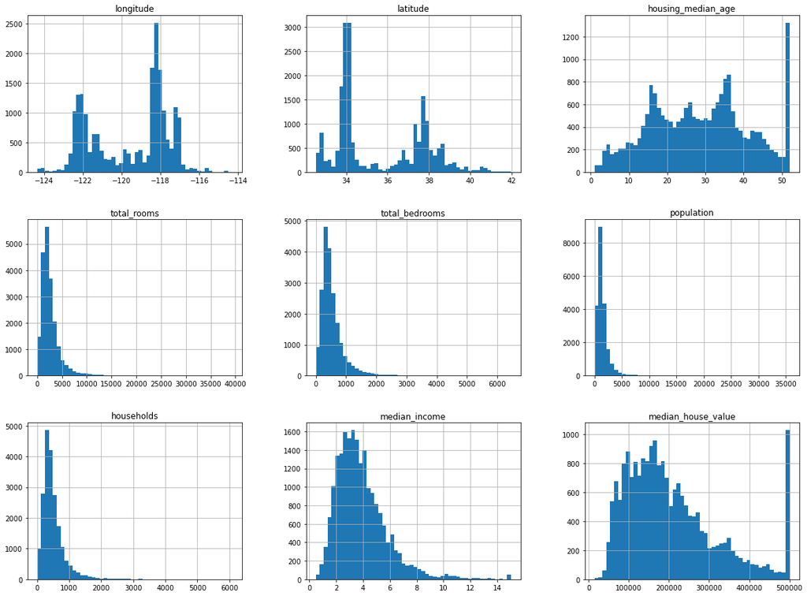

```python
housing.hist(bins=50, figsize=(20,15))
mpl.pyplot.savefig("desc_hist.png")
# mpl.pyplot.show()
```

```python
help(mpl.pyplot.hist)
```

[output not shown]

[output cut: 137 more lines]

[output not shown]

### What do you observe from the plots?

**median_income** - could it be $12?  
the numbers roughly represent tens of thousands of dollars

**median_age** - is it possible that the maximum age be just around 50-55?  
**median_house_value** - can the prices be not higher than $500,000  
both the values have been capped. This could seriously affect your learning algorithm's training in real life prediction. However, for now this is ok for the purpose of this lecture

**latitude &amp longitude** - they will not be fed as predictor to learning algorithm but could possibly help us see the data density from geogrphic point of view

**general observations** -

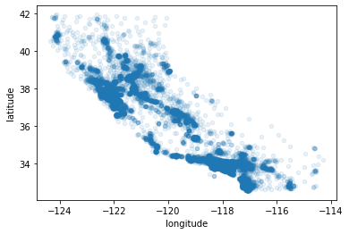

```python
housing.plot(kind='scatter', x = 'longitude', y = 'latitude', alpha = 0.1)
mpl.pyplot.show()
```

We can clearly visualise for which regions we have got more data points as compared to the rest by observing the high density areas on the plot. The alpha parameter of plot method has helped us to visualise the scatter plot's density

We can use some other interesting plotting strategies to explore some patterns in the dataset visually

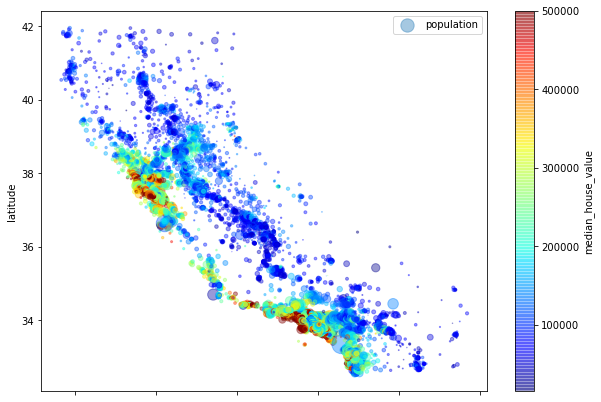

```python
housing.plot(kind = 'scatter', x = 'longitude', y = 'latitude', alpha = 0.4,
            s = housing['population']/100, label = 'population', figsize = (10,7),
            c = 'median_house_value', cmap = mpl.pyplot.get_cmap('jet'), colorbar=True)
mpl.pyplot.legend()
mpl.pyplot.show()
```

any observations?

1. higher prices near the edges probably facing the ocean ?

## Missing values - bedrooms

let's move back to lecture and build some concepts!

now that we are back let's check how many NA/missing values in 'total_bedrooms' are there

```python
housing['total_bedrooms'].isna().value_counts()
```

```
False    20433
True       207
Name: total_bedrooms, dtype: int64
```

Try : replace the missing values to some value (zero, mean, median, etc.)

note: make sure you try this on a copy of actual dataframe, rather than loosing the information from actual dataframe.

hint for mean and median, use python's mean and median methods

```python
housing_copy = housing.copy()
```

```python
housing.info()
```

```
<class 'pandas.core.frame.DataFrame'>
RangeIndex: 20640 entries, 0 to 20639
Data columns (total 10 columns):
 #   Column              Non-Null Count  Dtype
---  ------              --------------  -----
 0   longitude           20640 non-null  float64
 1   latitude            20640 non-null  float64
 2   housing_median_age  20640 non-null  float64
 3   total_rooms         20640 non-null  float64
 4   total_bedrooms      20433 non-null  float64
 5   population          20640 non-null  float64
 6   households          20640 non-null  float64
 7   median_income       20640 non-null  float64
 8   median_house_value  20640 non-null  float64
 9   ocean_proximity     20640 non-null  object
dtypes: float64(9), object(1)
memory usage: 1.6+ MB
```

```python
housing_copy['total_bedrooms'].fillna(0,inplace=True)
housing_copy.info()
```

```
<class 'pandas.core.frame.DataFrame'>
RangeIndex: 20640 entries, 0 to 20639
Data columns (total 10 columns):
 #   Column              Non-Null Count  Dtype
---  ------              --------------  -----
 0   longitude           20640 non-null  float64
 1   latitude            20640 non-null  float64
 2   housing_median_age  20640 non-null  float64
 3   total_rooms         20640 non-null  float64
 4   total_bedrooms      20640 non-null  float64
 5   population          20640 non-null  float64
 6   households          20640 non-null  float64
 7   median_income       20640 non-null  float64
 8   median_house_value  20640 non-null  float64
 9   ocean_proximity     20640 non-null  object
dtypes: float64(9), object(1)
memory usage: 1.6+ MB
```

```python
housing_copy = housing.copy()
```

```python
median = housing['total_bedrooms'].median()
housing_copy['total_bedrooms'].fillna(median, inplace = True)
housing_copy.info()
```

```
<class 'pandas.core.frame.DataFrame'>
RangeIndex: 20640 entries, 0 to 20639
Data columns (total 10 columns):
 #   Column              Non-Null Count  Dtype
---  ------              --------------  -----
 0   longitude           20640 non-null  float64
 1   latitude            20640 non-null  float64
 2   housing_median_age  20640 non-null  float64
 3   total_rooms         20640 non-null  float64
 4   total_bedrooms      20640 non-null  float64
 5   population          20640 non-null  float64
 6   households          20640 non-null  float64
 7   median_income       20640 non-null  float64
 8   median_house_value  20640 non-null  float64
 9   ocean_proximity     20640 non-null  object
dtypes: float64(9), object(1)
memory usage: 1.6+ MB
```

```python
housing.info()
```

```
<class 'pandas.core.frame.DataFrame'>
RangeIndex: 20640 entries, 0 to 20639
Data columns (total 10 columns):
 #   Column              Non-Null Count  Dtype
---  ------              --------------  -----
 0   longitude           20640 non-null  float64
 1   latitude            20640 non-null  float64
 2   housing_median_age  20640 non-null  float64
 3   total_rooms         20640 non-null  float64
 4   total_bedrooms      20433 non-null  float64
 5   population          20640 non-null  float64
 6   households          20640 non-null  float64
 7   median_income       20640 non-null  float64
 8   median_house_value  20640 non-null  float64
 9   ocean_proximity     20640 non-null  object
dtypes: float64(9), object(1)
memory usage: 1.6+ MB
```

another useful python supported imputation method is interpolate. You can try it in your own time.

[url to documentation](https://pandas.pydata.org/pandas-docs/stable/reference/api/pandas.DataFrame.interpolate.html#pandas.DataFrame.interpolate)  
[url to examples](https://pandas.pydata.org/pandas-docs/stable/user_guide/missing_data.html)

### now let's use K-NN for missing value imputation

```python
from fancyimpute import KNN
```

```python
housing_imp = housing.copy()
```

```python
list(housing_imp)
```

```
['longitude',
 'latitude',
 'housing_median_age',
 'total_rooms',
 'total_bedrooms',
 'population',
 'households',
 'median_income',
 'median_house_value',
 'ocean_proximity']
```

```python
housing_imp.info()
```

```
<class 'pandas.core.frame.DataFrame'>
RangeIndex: 20640 entries, 0 to 20639
Data columns (total 10 columns):
 #   Column              Non-Null Count  Dtype
---  ------              --------------  -----
 0   longitude           20640 non-null  float64
 1   latitude            20640 non-null  float64
 2   housing_median_age  20640 non-null  float64
 3   total_rooms         20640 non-null  float64
 4   total_bedrooms      20433 non-null  float64
 5   population          20640 non-null  float64
 6   households          20640 non-null  float64
 7   median_income       20640 non-null  float64
 8   median_house_value  20640 non-null  float64
 9   ocean_proximity     20640 non-null  object
dtypes: float64(9), object(1)
memory usage: 1.6+ MB
```

now didvide the dataset in to two subsets  
one subset should have all the rows with missing values, lets call this **housing_test**  
let the other subset be used as a training dataset for KNN, from where it can calculate distances and find nearest neighbours. let's call it **housing_train**

remember: KNN will build a function using all the columns except for 'totalbedrooms'.  
So, the rest of the columns would be independent variables of that function, i.e. $x{1}, x*{2}, ... , x*{n}$ <br> and 'total_bedroom' would be the dependent variable i.e. $y$ , as the function would use independent variables to predict outcome (dependent variable $y$). </font>

```python
# #create train dataset
# x_housing_imp_train = housing_imp[housing_imp['total_bedrooms'].notnull()].drop(columns = 'total_bedrooms')
# y_housing_imp_train = housing_imp[housing_imp['total_bedrooms'].notnull()]['total_bedrooms']


# #create test dataset
# x_housing_imp_test = housing_imp[housing_imp['total_bedrooms'].isnull()].drop(columns = 'total_bedrooms')
# y_housing_imp_train = housing_imp[housing_imp['total_bedrooms'].isnull()]['total_bedrooms']
```

```python
# housing_imp = KNN(k=3).fit_transform(housing_imp)
```

1. let's see how many distinct categories this variable has: </font>

```python
housing_imp['ocean_proximity'].unique()
```

```
array(['NEAR BAY', '<1H OCEAN', 'INLAND', 'NEAR OCEAN', 'ISLAND'],
      dtype=object)
```

```
2. We need to come up with a mapping from  categorical to numerical value
```

```python
proximity_mapping = {'ocean_proximity': {'INLAND': 1, 'NEAR OCEAN': 2, 'NEAR BAY': 3, 'ISLAND': 4, '<1H OCEAN':5}}
proximity_mapping.items()
```

```
dict_items([('ocean_proximity', {'INLAND': 1, 'NEAR OCEAN': 2, 'NEAR BAY': 3, 'ISLAND': 4, '<1H OCEAN': 5})])
```

There is another way of handling categorical data in pandas  
converting the categorical datatype from object to pandas **_categorical_** data type.  
now that you have developed an understanding on why do we need to convert categorical variables to numbers and how to do it. It would be good to have a look and go through the following webpage which describes pandas's categorical data type and what goes on in the backend. The following webpage also shows some usecases and you may be able to infer that why doesn't it make any difference thatw e are not using pandas categorical dataype, instead simply mapping the categories to numbers. [url to pandas categorical datatype documentation](https://pandas.pydata.org/pandas-docs/stable/user_guide/categorical.html)

Note: if we were to change the datatype, the action is of changing datatype of a variable is called typecasting. It is performed by using .astype() method on the variable  
Example: `housing_imp['ocean_proximity'].astype('category')`

```python
housing_imp.replace(proximity_mapping, inplace = True)
housing_imp.head()
```

|  | longitude | latitude | housing_median_age | total_rooms | total_bedrooms | population | households | median_income | median_house_value | ocean_proximity |
| --- | --- | --- | --- | --- | --- | --- | --- | --- | --- | --- |
| 0 | -122.23 | 37.88 | 41.0 | 880.0 | 129.0 | 322.0 | 126.0 | 8.3252 | 452600.0 | 3 |
| 1 | -122.22 | 37.86 | 21.0 | 7099.0 | 1106.0 | 2401.0 | 1138.0 | 8.3014 | 358500.0 | 3 |
| 2 | -122.24 | 37.85 | 52.0 | 1467.0 | 190.0 | 496.0 | 177.0 | 7.2574 | 352100.0 | 3 |
| 3 | -122.25 | 37.85 | 52.0 | 1274.0 | 235.0 | 558.0 | 219.0 | 5.6431 | 341300.0 | 3 |
| 4 | -122.25 | 37.85 | 52.0 | 1627.0 | 280.0 | 565.0 | 259.0 | 3.8462 | 342200.0 | 3 |

```python
housing.head()
```

|  | longitude | latitude | housing_median_age | total_rooms | total_bedrooms | population | households | median_income | median_house_value | ocean_proximity |
| --- | --- | --- | --- | --- | --- | --- | --- | --- | --- | --- |
| 0 | -122.23 | 37.88 | 41.0 | 880.0 | 129.0 | 322.0 | 126.0 | 8.3252 | 452600.0 | NEAR BAY |
| 1 | -122.22 | 37.86 | 21.0 | 7099.0 | 1106.0 | 2401.0 | 1138.0 | 8.3014 | 358500.0 | NEAR BAY |
| 2 | -122.24 | 37.85 | 52.0 | 1467.0 | 190.0 | 496.0 | 177.0 | 7.2574 | 352100.0 | NEAR BAY |
| 3 | -122.25 | 37.85 | 52.0 | 1274.0 | 235.0 | 558.0 | 219.0 | 5.6431 | 341300.0 | NEAR BAY |
| 4 | -122.25 | 37.85 | 52.0 | 1627.0 | 280.0 | 565.0 | 259.0 | 3.8462 | 342200.0 | NEAR BAY |

Since we made some changes to a copy of the original dataset while demonstrating other methods , let's just make sure that we haven't over written the original dataset.

```python
housing_imp['ocean_proximity'].value_counts()
```

```
5    9136
1    6551
2    2658
3    2290
4       5
Name: ocean_proximity, dtype: int64
```

Let's call the KNN impute method again and see if it goes smooth!

```python
housing_imp.info()
```

```
<class 'pandas.core.frame.DataFrame'>
RangeIndex: 20640 entries, 0 to 20639
Data columns (total 10 columns):
 #   Column              Non-Null Count  Dtype
---  ------              --------------  -----
 0   longitude           20640 non-null  float64
 1   latitude            20640 non-null  float64
 2   housing_median_age  20640 non-null  float64
 3   total_rooms         20640 non-null  float64
 4   total_bedrooms      20433 non-null  float64
 5   population          20640 non-null  float64
 6   households          20640 non-null  float64
 7   median_income       20640 non-null  float64
 8   median_house_value  20640 non-null  float64
 9   ocean_proximity     20640 non-null  int64
dtypes: float64(9), int64(1)
memory usage: 1.6 MB
```

```python
housing_imp = KNN(k=3).fit_transform(housing_imp)
```

[output not shown]

[output cut: 152 more lines]

[output not shown]

```python
housing_imp
```

```
array([[-1.2223e+02,  3.7880e+01,  4.1000e+01, ...,  8.3252e+00,
         4.5260e+05,  3.0000e+00],
       [-1.2222e+02,  3.7860e+01,  2.1000e+01, ...,  8.3014e+00,
         3.5850e+05,  3.0000e+00],
       [-1.2224e+02,  3.7850e+01,  5.2000e+01, ...,  7.2574e+00,
         3.5210e+05,  3.0000e+00],
       ...,
       [-1.2122e+02,  3.9430e+01,  1.7000e+01, ...,  1.7000e+00,
         9.2300e+04,  1.0000e+00],
       [-1.2132e+02,  3.9430e+01,  1.8000e+01, ...,  1.8672e+00,
         8.4700e+04,  1.0000e+00],
       [-1.2124e+02,  3.9370e+01,  1.6000e+01, ...,  2.3886e+00,
         8.9400e+04,  1.0000e+00]])
```

the fancy_impute package, returns an n-dimesional numpy array after imputing  
we need to convert the nd array to pandas dataframe

```python
housing_imp = pd.DataFrame(housing_imp, index = housing.index, columns = housing.columns)
```

```python
housing_imp.info()
```

```
<class 'pandas.core.frame.DataFrame'>
RangeIndex: 20640 entries, 0 to 20639
Data columns (total 10 columns):
 #   Column              Non-Null Count  Dtype
---  ------              --------------  -----
 0   longitude           20640 non-null  float64
 1   latitude            20640 non-null  float64
 2   housing_median_age  20640 non-null  float64
 3   total_rooms         20640 non-null  float64
 4   total_bedrooms      20640 non-null  float64
 5   population          20640 non-null  float64
 6   households          20640 non-null  float64
 7   median_income       20640 non-null  float64
 8   median_house_value  20640 non-null  float64
 9   ocean_proximity     20640 non-null  float64
dtypes: float64(10)
memory usage: 1.6 MB
```

now that all rows have been imputed, let's see what the data looks like now, and compare it to when there were missing values

```python
housing.describe()
```

|  | longitude | latitude | housing_median_age | total_rooms | total_bedrooms | population | households | median_income | median_house_value |
| --- | --- | --- | --- | --- | --- | --- | --- | --- | --- |
| count | 20640.000000 | 20640.000000 | 20640.000000 | 20640.000000 | 20433.000000 | 20640.000000 | 20640.000000 | 20640.000000 | 20640.000000 |
| mean | -119.569704 | 35.631861 | 28.639486 | 2635.763081 | 537.870553 | 1425.476744 | 499.539680 | 3.870671 | 206855.816909 |
| std | 2.003532 | 2.135952 | 12.585558 | 2181.615252 | 421.385070 | 1132.462122 | 382.329753 | 1.899822 | 115395.615874 |
| min | -124.350000 | 32.540000 | 1.000000 | 2.000000 | 1.000000 | 3.000000 | 1.000000 | 0.499900 | 14999.000000 |
| 25% | -121.800000 | 33.930000 | 18.000000 | 1447.750000 | 296.000000 | 787.000000 | 280.000000 | 2.563400 | 119600.000000 |
| 50% | -118.490000 | 34.260000 | 29.000000 | 2127.000000 | 435.000000 | 1166.000000 | 409.000000 | 3.534800 | 179700.000000 |
| 75% | -118.010000 | 37.710000 | 37.000000 | 3148.000000 | 647.000000 | 1725.000000 | 605.000000 | 4.743250 | 264725.000000 |
| max | -114.310000 | 41.950000 | 52.000000 | 39320.000000 | 6445.000000 | 35682.000000 | 6082.000000 | 15.000100 | 500001.000000 |

```python
housing_imp.describe()
```

|  | longitude | latitude | housing_median_age | total_rooms | total_bedrooms | population | households | median_income | median_house_value | ocean_proximity |
| --- | --- | --- | --- | --- | --- | --- | --- | --- | --- | --- |
| count | 20640.000000 | 20640.000000 | 20640.000000 | 20640.000000 | 20640.000000 | 20640.000000 | 20640.000000 | 20640.000000 | 20640.000000 | 20640.000000 |
| mean | -119.569704 | 35.631861 | 28.639486 | 2635.763081 | 537.584021 | 1425.476744 | 499.539680 | 3.870671 | 206855.816909 | 3.121948 |
| std | 2.003532 | 2.135952 | 12.585558 | 2181.615252 | 420.509777 | 1132.462122 | 382.329753 | 1.899822 | 115395.615874 | 1.776068 |
| min | -124.350000 | 32.540000 | 1.000000 | 2.000000 | 1.000000 | 3.000000 | 1.000000 | 0.499900 | 14999.000000 | 1.000000 |
| 25% | -121.800000 | 33.930000 | 18.000000 | 1447.750000 | 296.000000 | 787.000000 | 280.000000 | 2.563400 | 119600.000000 | 1.000000 |
| 50% | -118.490000 | 34.260000 | 29.000000 | 2127.000000 | 435.000000 | 1166.000000 | 409.000000 | 3.534800 | 179700.000000 | 3.000000 |
| 75% | -118.010000 | 37.710000 | 37.000000 | 3148.000000 | 647.000000 | 1725.000000 | 605.000000 | 4.743250 | 264725.000000 | 5.000000 |
| max | -114.310000 | 41.950000 | 52.000000 | 39320.000000 | 6445.000000 | 35682.000000 | 6082.000000 | 15.000100 | 500001.000000 | 5.000000 |

note: compare the values **Count**, **mean**, and **std**

The overall look and feel of the dataset remained the same  
unfortunately we do not have a copy of the original dataset, where no values where was deliberately taken off to create missing values. Otherwise we could have compared KNN imputer's accuracy by comparing the actual values and imputed values

### Data Transformation

#### Handling Skewness

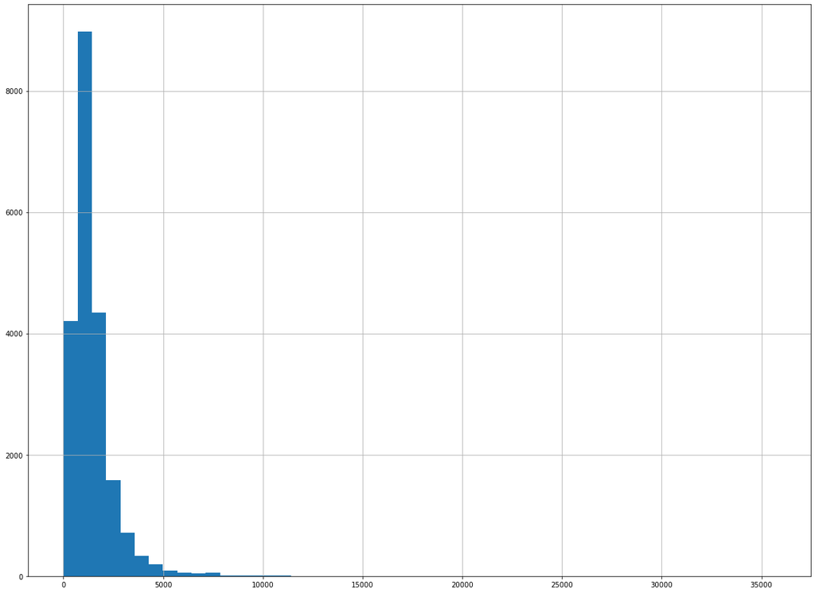

```python
housing_imp['population'].hist(bins=50, figsize=(20,15))

# mpl.pyplot.show()
```

```python
housing_imp['population'].describe()
```

```
count    20640.000000
mean      1425.476744
std       1132.462122
min          3.000000
25%        787.000000
50%       1166.000000
75%       1725.000000
max      35682.000000
Name: population, dtype: float64
```

```python
import numpy as np
(np.log10(housing_imp['population'])).describe()
```

```
count    20640.000000
mean         3.050535
std          0.320737
min          0.477121
25%          2.895975
50%          3.066699
75%          3.236789
max          4.552449
Name: population, dtype: float64
```

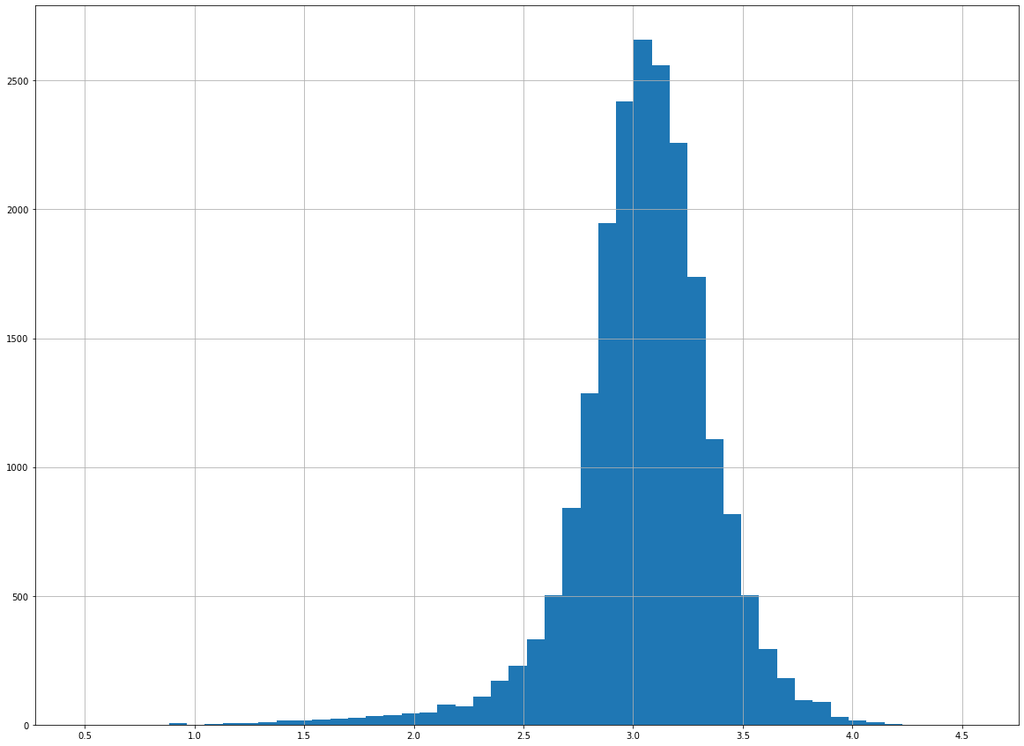

```python
(np.log10(housing['population'])).hist(bins=50, figsize=(20,15))
```

Transforming using base 10 log has pretty much resolved the skew. But this may not be the case every time. So let's learn applying advanced transformation methods as discussed earlier.

```python
population_tf = housing_imp['population'].copy()
```

```python
from scipy import stats
```

```python
population_tf, lambda_ = stats.boxcox(population_tf)
```

```python
print(lambda_)
```

```
0.23576757812051324
```

```python
population_tf = pd.Series(population_tf)
population_tf.describe()
```

```
count    20640.000000
mean        18.299675
std          3.702327
min          1.254015
25%         16.189687
50%         18.173806
75%         20.342155
max         45.973809
dtype: float64
```

```python
housing_imp['population'].describe()
```

```
count    20640.000000
mean      1425.476744
std       1132.462122
min          3.000000
25%        787.000000
50%       1166.000000
75%       1725.000000
max      35682.000000
Name: population, dtype: float64
```

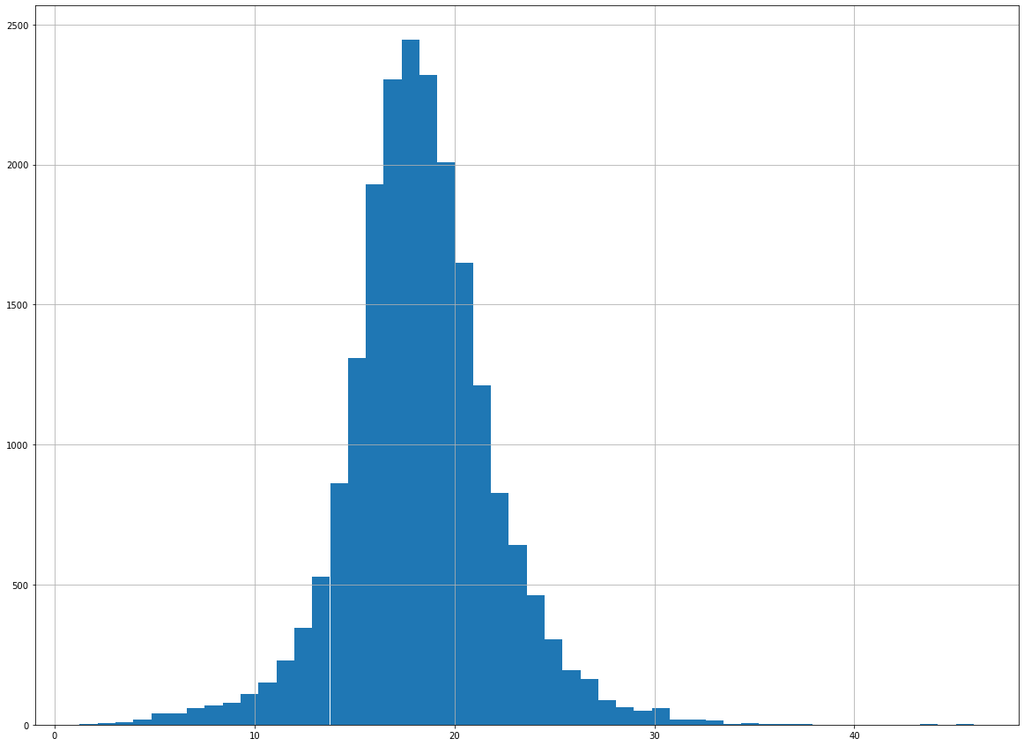

```python
(population_tf).hist(bins=50, figsize=(20,15))
```

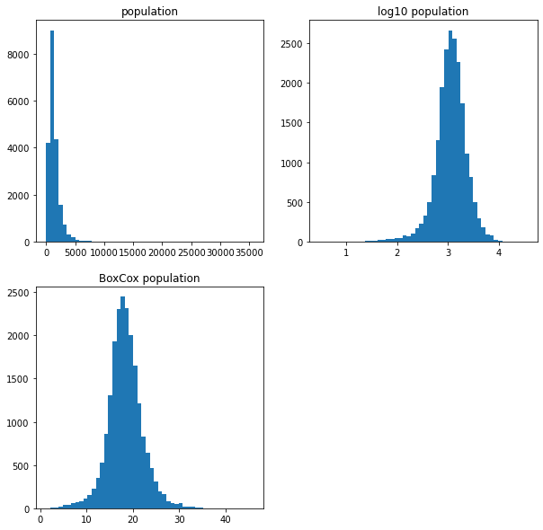

```python
fig, axes = mpl.pyplot.subplots(nrows = 2, ncols = 2, figsize = (10,10))

ax0,ax1,ax2,ax3 = axes.flatten()

ax0.hist (housing_imp['population'], bins=50)
ax0.set_title('population')
ax1.hist (np.log10(housing_imp['population']), bins = 50)
ax1.set_title('log10 population')
ax2.hist(population_tf, bins = 50)
ax2.set_title('BoxCox population')
ax3.set_visible(False)

mpl.pyplot.show()
```

#### Scaling

```python
from sklearn.preprocessing import StandardScaler as ss
housing.columns
```

```
Index(['longitude', 'latitude', 'housing_median_age', 'total_rooms',
       'total_bedrooms', 'population', 'households', 'median_income',
       'median_house_value', 'ocean_proximity'],
      dtype='object')
```

```python
ex = housing_imp[['housing_median_age', 'total_rooms',
       'total_bedrooms', 'population', 'households', 'median_income',
       'median_house_value']].copy()
ex.head()
ex = ss().fit_transform(ex)
```

```python
ex = pd.DataFrame(ex, index = housing.index,
                      columns = ['housing_median_age', 'total_rooms',
                                'total_bedrooms', 'population',
                                'households', 'median_income',
                                'median_house_value'])
ex.head()
```

|  | housing_median_age | total_rooms | total_bedrooms | population | households | median_income | median_house_value |
| --- | --- | --- | --- | --- | --- | --- | --- |
| 0 | 0.982143 | -0.804819 | -0.971663 | -0.974429 | -0.977033 | 2.344766 | 2.129631 |
| 1 | -0.607019 | 2.045890 | 1.351763 | 0.861439 | 1.669961 | 2.332238 | 1.314156 |
| 2 | 1.856182 | -0.535746 | -0.826598 | -0.820777 | -0.843637 | 1.782699 | 1.258693 |
| 3 | 1.856182 | -0.624215 | -0.719582 | -0.766028 | -0.733781 | 0.932968 | 1.165100 |
| 4 | 1.856182 | -0.462404 | -0.612567 | -0.759847 | -0.629157 | -0.012881 | 1.172900 |

### Feature Reduction

Now let's try PCA in python to reduce features

```python
from sklearn.decomposition import PCA
```

```python
# make an instance of the model
pca = PCA(n_components = .95)
```

0.95 means that scikit-learn choose the minimum number of principal components such that 95% of the variance is retained

You can instead tell PCA how many PCs you want as follows  
`pca = PCA(n_components = 2)`

```python
ex_pca = pca.fit_transform(ex)
ex_pca
```

```
array([[-1.80639205,  3.30385307,  0.43529667,  0.26273499],
       [ 3.21331779,  2.43479649, -0.20471277,  0.58705946],
       [-1.72308269,  2.32186252,  1.27532603,  0.74249704],
       ...,
       [-0.31269158, -1.49296362, -0.91116638, -0.38054765],
       [-0.7246362 , -1.44516593, -0.95391554, -0.28818225],
       [ 0.27930056, -1.30312523, -0.93677036, -0.11931265]])
```

```python
pca.n_components_
```

```
4
```

```python
ex_pca = pd.DataFrame(ex_pca, columns = ['PC1','PC2','PC3','PC4'])
ex_pca.head()
```

|  | PC1 | PC2 | PC3 | PC4 |
| --- | --- | --- | --- | --- |
| 0 | -1.806392 | 3.303853 | 0.435297 | 0.262735 |
| 1 | 3.213318 | 2.434796 | -0.204713 | 0.587059 |
| 2 | -1.723083 | 2.321863 | 1.275326 | 0.742497 |
| 3 | -1.683938 | 1.639319 | 1.456496 | 0.234768 |
| 4 | -1.548849 | 0.981707 | 1.676732 | -0.370840 |

```python
pca.explained_variance_ratio_
```

```
array([0.55563886, 0.24290715, 0.12915478, 0.04143364])
```

```python
corr = ex.loc[: , ex.columns != 'median_house_value'].corr()
corr
```

|  | housing_median_age | total_rooms | total_bedrooms | population | households | median_income |
| --- | --- | --- | --- | --- | --- | --- |
| housing_median_age | 1.000000 | -0.361262 | -0.321147 | -0.296244 | -0.302916 | -0.119034 |
| total_rooms | -0.361262 | 1.000000 | 0.930447 | 0.857126 | 0.918484 | 0.198050 |
| total_bedrooms | -0.321147 | 0.930447 | 1.000000 | 0.877728 | 0.978675 | -0.007021 |
| population | -0.296244 | 0.857126 | 0.877728 | 1.000000 | 0.907222 | 0.004834 |
| households | -0.302916 | 0.918484 | 0.978675 | 0.907222 | 1.000000 | 0.013033 |
| median_income | -0.119034 | 0.198050 | -0.007021 | 0.004834 | 0.013033 | 1.000000 |

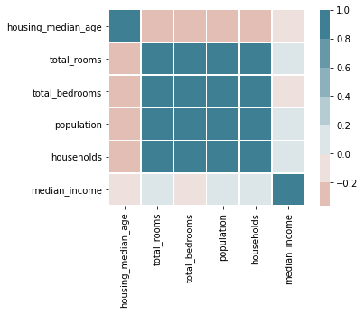

```python
import seaborn as sns

cor_mat = sns.heatmap(
    corr,
  center = 0,
    cmap = sns.diverging_palette(20,220, n = 10),
    square = True,
    linewidths = 0.5
)
```

Some predictors are strongly correlated. Wonder what the reason could be?

```
1. total_rooms & total_bedrooms,
2. total_rooms & population,
3. total_rooms & households
```